# CalSim Overview

01/03/23

## CalSim Model Summary

California Simulation (CalSim) is a water resources planning model of the Central Valley Project (CVP) and State Water Project (SWP) operations.

CalSim simulates the operations of the State Water Project (SWP) and the Central Valley Project (CVP), along with much of the water resources infrastructure in the Central Valley of California and the Sacramento-San Joaquin Delta region. It models various aspects of water management, including:

- water storage,
- conveyance,
- deliveries,
- hydropower generation,
- and flows

Additionally, CalSim simulates the interactions between these components and their impacts on water availability, reliability, and overall system performance.

### Architecture

The following sections describe key model components. The diagram below is a simplified version of CalSim data inputs and how they contribute to the mass balance of the watersheds.

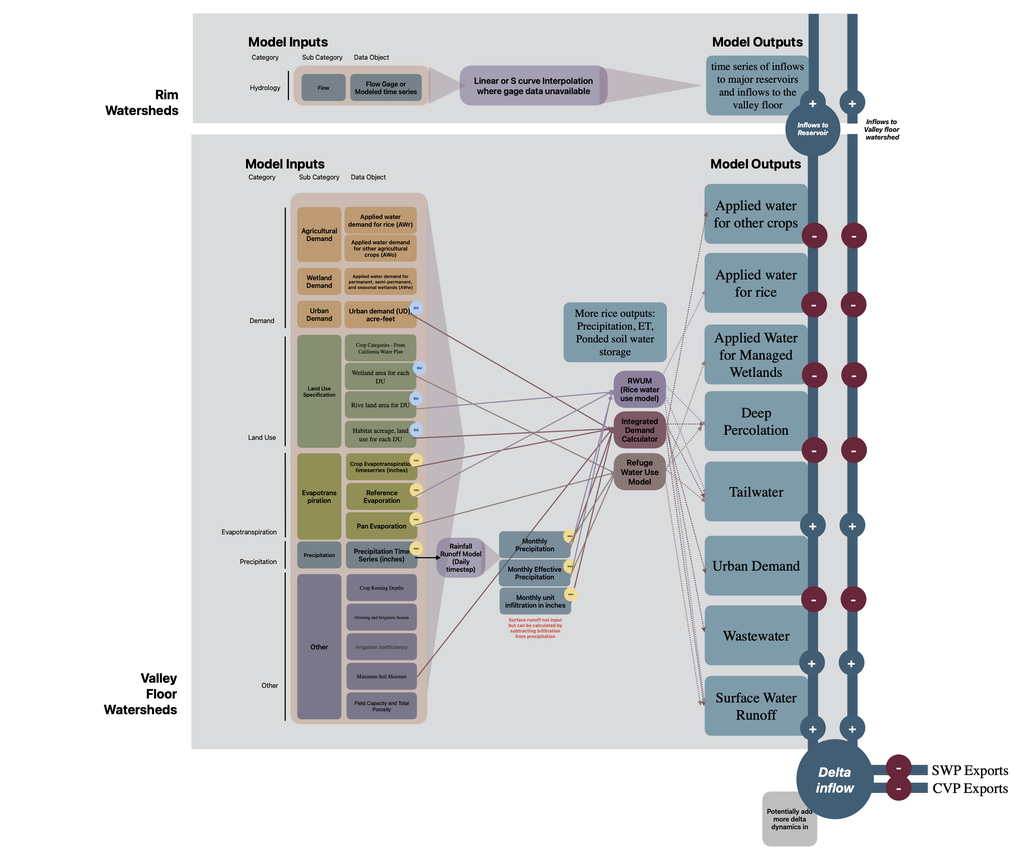

```r
setwd("data-raw")
knitr::include_graphics(path = "calsim_conceptual_diagram.png")
```

#### Water Resource Integrated Modeling System (WRIM)

The Water Resource Integrated Modeling System (WRIM) provides the modeling framework and software for CalSim. WRIMS is a versatile water resources modeling system designed to assess operational alternatives in large and intricate river basins. It incorporates a simulation language for flexible specification of operational criteria, a linear programming solver for making efficient water allocation decisions, and graphics capabilities ([WRIM](https://water.ca.gov/Library/Modeling-and-Analysis/Modeling-Platforms/Water-Resource-Integrated-Modeling-System)).

- Simulation language for operations criteria
- Linear programming solver for water allocation decisions
- Graphic capabilities

#### Supporting Models

```r
# Fill in additional info based on page 169.
models <- readxl::read_excel("data-raw/calsim_inputs.xlsx", sheet = 2)
knitr::kable(models)
```

[output not shown]

#### CalSimHydro

CalSimHydro is the CalSim 3.0 Hydrology Preprocessor. CalSimHydro consists of the following components described in [CalSimHydro Tool - A Web-based interactive tool for the CalSim 3.0 Hydrology Prepropessor](https://www.researchgate.net/publication/258461694_CalSimHydro_Tool_-_A_Web-based_interactive_tool_for_the_CalSim_30_Hydrology_Prepropessor):

1. A Rainfall-Runoff Model to compute monthly infiltration
2. a Soil moisture and demand calculator (IDC) that estimates surface runoff, deep percolation, and water demands for natural vegetation cover and various crops other than rice
3. a Rice Water Use Model to compute the water demands, deep percolation, irrigation return flow, and runoff from precipitation for the rice fields
4. a Refuge Water Use Model that simulates the ponding operations for managed wetlands, and
5. a Data Aggregation and Transfer Module to aggregate the outputs from the above modules and transfer them to the CalSim SV input file.

#### System Components

Watersheds in CalSim are categorized as either Rim or Valley Floor watersheds.

- Rim: foothill and mountain watersheds characterized by steep slopes, shallow soils, limited aquifer, not developed
- Valley Floor: located between Upper watersheds and Delta; extensively developed, highly managed, rich agricultural land, urban areas

CalSim 3 uses defined Water Budget Areas (WBA), that have been developed to help define the enhanced spatial resolution of CalSim 3. WBAs are used to:

- Provide a structure to simplify the organization, explanation, and presentation of CalSim 3 data, code, and results.
- Define the boundary of non-district agricultural water users within a region who are aggregated to a single demand unit in CalSim 3.
- Define the boundary of scattered water users whose water supplies for domestic (or industrial) use are self-produced, who rely on groundwater, and who are represented in CalSim 3 by a single demand unit.
- Define the spatial resolution of hydrologic input data for calculating agricultural demands (i.e., precipitation and evapotranspiration (ET)).

Additionally, the refined spatial scale is organized around demand units are formulated so that water users within a demand unit have similar water rights, water contracts, source(s) of water, soils, land use, and general water delivery and irrigation efficiencies. Demand units are the smallest computational unit and are generated based on the following data sources:

- Water district and water agency boundaries and service areas obtained from the Cal-Atlas Geospatial Clearinghouse (formerly the California Spatial Information Library), which comprises separate GIS layers for Federal, State, and private water districts. These data are also available from DWR (2022a).
- County LAFCO reports on water purveyors in their respective counties (LAFCO, 2022).0F
- County land-use surveys undertaken by DWR’s Division of Regional Assistance (formerly Division of Planning and Local Assistance) (DWR, 2022b).
- County and regional integrated water resources plans and integrated water management plans.
- CalSim II documentation (Reclamation, 2007).
- Reclamation CVP water supply contract renewal and supporting environmental documents (Reclamation, 2022).

CalSim is developed in the form of a node-arc network where nodes represent specific locations and arcs represent flow between nodes, [here](https://data.cnra.ca.gov/dataset/2395530a-5421-487e-921e-d6e594f23ac6/resource/3ec8338e-31d9-4dd3-93df-8d60ee6ec3d2/download/cs3_networkschematic_integrated_10_11_2022.pdf) is a full schematic diagram of the system.

The following Node types are included:

- storage nodes - represented by blue triangle, start with “S_”
- conveyence nodes
  - Outline colors:
    - Blue - natural stream channel
    - Gray - man-made canal, drain or bypass
  - Fill colors:
    - Green - Return flow split node Approximates diffuse networks of drains
    - Gray - streamflow gaging station
- facility nodes
  - wastewater treatment plants
  - water treatment plants
  - pump stations
- demand units
  - Dashed line signifies demand unit is limited to groundwater supplies
  - Single, solid line signifies demand unit is limited to surface water supplies
  - Double, solid line signifies demand unit has access to
  - both surface water and groundwater supplies
  - Blue-green fill denotes managed wetland demand unit
  - Green fill denotes agricultural demand unit
  - Grey fill denotes urban demand unit

Arcs represent averge monthly flows to, from or between nodes. Flow direction indicated by arrow. A few different types of arcs are includes:

- C (blue): channel - river or stream flows
- C (gray): channel - canal or drain flows
- SP (black dashed) : Spill - spill or flood bypass flows
- D (red) : Diversion - typically to demand unit
- R (green) : Return Flow - typically from demand unit
- I (blue) : Inflow - rim watershed inflows
- SR (blue) : Surface Runoff - rainfall-runoff within the valley floor

### Assumptions

Hydroloic Modeling assumptions:

- The first assumption categorizes foothill and mountainous ‘rim’ watersheds surrounding the Central Valley as relatively undeveloped, with minimal changes in land use over time affecting natural outflows. These watersheds typically exhibit complex topography, steep slopes, shallow soils, and limited groundwater aquifer systems. Runoff in these areas is predominantly influenced by the snowfall and snowmelt cycle, with precipitation quickly returning to streams as baseflow. Groundwater is not extensively utilized as a water supply source in these upland watersheds.
- The second assumption pertains to the ‘valley floor’ watersheds, which have undergone extensive agricultural development and include significant urban areas. Human impacts on the environment strongly influence the timing and volume of runoff in these areas. Deep percolation from precipitation and irrigation contributes to aquifer recharge, which is closely connected to the stream system. Groundwater serves as a crucial water source for both agricultural and urban purposes, leading to significant changes in groundwater storage over time.

### Accessibility

There are multiple components of accessibility being evaluated:

- documentation
- model code/software openly available for download
- model parameters and results available for download
- user is able to run the model without extensive expertise

**License:** WRIMS 2 is copyrighted by the State of California Department of Water Resources. It is licensed under the Eclipse Public License, Version 1.0. See Eclipse Public License for more details. However, WRIMS 2 includes a commercial solver named XA which requires a license.

**Download Links:**

- *Code and Software:* WRIMS 2.0 guides and software are available for download at the [DWR WRIMS site](https://water.ca.gov/Library/Modeling-and-Analysis/Modeling-Platforms/Water-Resource-Integrated-Modeling-System).
- *Inputs and Outputs:* The full CalSim model package is available for download [here](https://catalog.data.gov/dataset/calsim-3-0-release-7f092), however there is no clear documentation on how to review or run the downloaded model. This includes model parameters/inputs but it is not clear how to navigate the file structure to find specific inputs.

**Running the Model**

In progress: Evaluating how accessible running the model is.

### Update procedure

There is no standard update schedule for CalSim; rather, model updates follow updates in regulations. The following summarizes the updates that have been made:

- 2000: DWR created Water Resources Integrated Modeling System (WRIMS)
- 2002: Reclamation and DWR subsequently made two public releases of CalSim II, known as benchmark studies, on May 17, 2002, and September 30, 2002 (CalSim III Main Report).
- 2002 - 2021: Iterative updates to CalSim 2 regulatory rulesets.
- 2022: CalSim 3 produced

#### Primary differences between CalSimII and CalSim 3

Updates of CalSim 3 aim to enhance the accuracy, comprehensiveness, and usability of CalSim 3 for water resources management in California, addressing various aspects of hydrology, water demand, groundwater-surface water interactions, and model transparency. CalSim 3 objectives described in main report.

Spatial Resolution and Representation:

- Adoption of a finer spatial resolution depicting major stream networks, surface water diversions, and water agencies in the Central Valley.
- Association of water users with their local surface water supply sources and/or groundwater use.
- Improved representation of mountain and foothill watersheds surrounding the Central Valley floor, including explicit representation of storage regulation and diversions within these watersheds, and improved estimates of unimpaired flows based on historical gauge data.
- Simulation of all major water supply reservoirs.

Updated Hydrology Modeling:

- Implementation of a unified land-use-based hydrology model for the Central Valley floor, including explicit representation of surface runoff contributing to streamflows.
- Refinement of water demands using data collected from the California Water Plan, local and regional planning studies, and calibration of water use efficiency factors using historical diversion data.

Groundwater-Surface Water Interaction:

- Development of a spatially discrete groundwater module with a resolution similar to the California Central Valley Simulation Model (C2VSim) for simulating groundwater heads and stream-aquifer interaction.

Standardization and Documentation:

- Adoption of standardized nomenclature and model structure to provide greater clarity and transparency in the model.
- Increased documentation through the main report and associated appendices.

Simulation Period and Software Enhancements:

- Extension of the simulation period through the water year 2015.
- Improvement of model result presentation and comparison between scenarios through enhancements in the WRIMS software.

#### Scenarios Produced

[output not shown]

### Data Inputs

Data Inputs to CalSim 3 were summarized based on Chapters 4, 5, and 6 of the main report. Inputs described in the main report are summarized in the table below:

```r
# Fill in additional info based on page 169.
data_inputs <- readxl::read_excel("data-raw/calsim_inputs.xlsx", sheet = 1)
knitr::kable(data_inputs)
```

[output not shown]

#### Rim Watershed Modeling Inputs

##### Hydraulic Inputs

Rim watersheds - modeled using unimpaired runoff, utilize gage data directly where available to create a preprocessed time series of unimpaired runoff. This time series utilizes the following data sources:

- USGS (no specifics on what USGS data is used, or how to access)
- DWR (no specifics on what DWR data is used, or how to access)
- USACE (no specifics on what USACE data is used, or how to access)
- Reclamation (no specifics on what Reclamation data is used, or how to access)
- Data stored in text files as part of DWR’s “COMP” model (no specifics on what COMP model data is used, or how to access)

These data sources are not described in depth and no links to the sources are provided in the CalSim 3 main report.

When there are gaps in gage data or there is no available gage data for a rim watershed, a synthetic timeseries was developed using a linear interpolation approach (when there is some gage data, but only for a limited timeseries) or a S-Curve Method (Percent Deviation Method) to scale flow based on a similar watershed (when there is no gage data available from any time period). See section 5-14 for additional information on methods for producing synthetic timeseries.

To see the method used for each rim watershed and the specific gage utilized, refer to table Table 5-1: Data Sources and Calculation Methods, Sacramento River Hydrologic Region or Table 5-5: Data Sources and Calculation Methods, San Joaquin River Hydraulic Region in the main report

#### Valley Floor Watershed Modeling Inputs

##### Hydraulic Inputs

CalSim simulates both Surface Water and Groundwater dynamics for Valley Floor Watersheds. Inputs are preprocessed in a series of models that are ran prior to CalSim 3 including:

- IDC = Integrated Demand Calculator
- RRM = Rainfall-Runoff Model
- RWUM = Rice Water Use Model
- WWUM = Wetland Water Use Model

The following timeseries data are used directly in the above models:

- Surface runoff (SR) from precipitation
- Applied water demand for rice (AWr)
- Applied water demand for other agricultural crops (AWo)
- Applied water demand for permanent, semi-permanent, and seasonal wetlands (AWw)
- Urban demand (UD), combining indoor and outdoor components
- Tailwater (TW) from irrigated agricultural land
- Wastewater (WW) return flows from wastewater treatment plants
- Deep percolation (DP) from all land-use classes

No links to the sources are provided in the CalSim 3 main report.

##### Land Use

- Land Use
- Land Use Surveys
- Remote Sensing Data
- Historical and Current (Agricultural Land, Urban Land, Managed Wetlands, Native Vegetation)

Evaporation and Evapotranspiration (?) Valley Surface Runoff

#### Delta Regions

Precipitation

- NCDC Gaged Point Precipitation
- PRISM Distributed Precipitation Grid

Evaporation and Evapotranspiration (?)

#### Water Demand - Monthly

Demand is represented through catchment objects divided into: agricultural, urban, wetland refuge

**Agricultural Water Demand Data Sources**

- Water district and water agency boundaries and service areas obtained from the Cal-Atlas Geospatial Clearinghouse (formerly the California Spatial Information Library), which comprises separate GIS layers for Federal, State, and private water districts. These data are also available from DWR (2022a).
- County LAFCO reports on water purveyors in their respective counties (LAFCO, 2022)
- County land-use surveys undertaken by DWR’s Division of Regional Assistance (formerly Division of Planning and Local Assistance) (DWR, 2022b).
- County and regional integrated water resources plans and integrated water management plans.
- CalSim II documentation (Reclamation, 2007).
- Reclamation CVP water supply contract renewal and supporting environmental documents (Reclamation, 2022).

**Urban Water Demand Data Sources**

- Urban Water Management Plans (UWMP)
- Integrated Regional Water Management Plans (IRWMP)
- Drinking Water Source Assessments
- U.S. Environmental Protection Agency (EPA)
- California Water Plan, Update 2018

**Wetland Water Demand Data Sources**

- Report on Refuge Water Supply Investigations, Central Valley Hydrologic Basin, California (Reclamation, 1989a)
- San Joaquin Basin Action Plan/Kesterson Mitigation Plan (Reclamation, 1989b)
- Central Valley Joint Venture Implementation Plan (USFWS, 2006)
- Refuge water management plans (Reclamation, 2022a)
- Refuge water supply environmental documentation (Reclamation, 2022b)
- Reclamation water supply contract documents with Grassland WD, CDFW, USFWS, and MOUs with USFWS (Reclamation, 2022c)

**Contracts and Water Rights**

- Central Valley Project
- State Water Project
- Non-Project Water Users, Sacramento River Region
- Non-Project Water Users, San Joaquin River Region

### Model Validation procedures

## Spatial & Temporal Coverage

Watershed boundaries were developed using CalWater 2.2.1 and the USGS 12-digit Hydrologic Unit Code (HUC) watersheds.

Click [here](https://data.cnra.ca.gov/dataset/2395530a-5421-487e-921e-d6e594f23ac6/resource/3ec8338e-31d9-4dd3-93df-8d60ee6ec3d2/download/cs3_networkschematic_integrated_10_11_2022.pdf) to download the full model network schematic.

## Data use and limitations

Valley Wide Analysis - pros, good coverage of the system, can model how different operations would cause different flow at a relatively fine scale. cons, monthly time scale is limited for use in biological modeling, monthly timesep does not capture the fine scale resolution that biological organisms experience.

### Questions

- Is there a conceptual model anywhere to describe the CalSim modeling framework